# Practical Machine Learning - Course Project

Soumya Satyakanta Sethi

This analysis meant to be the basis for the course quiz and a prediction assignment writeup. The main goal of the project is to predict the manner in which 6 participants performed some exercise as described below. This is the “classe” variable in the training set. The machine learning algorithm described here is applied to the 20 test cases available in the test data for prediction.

## Dataset Overview

The data for this project come from http://groupware.les.inf.puc-rio.br/har. A short description of the datasets content from the authors’ website:

“Six young health participants were asked to perform one set of 10 repetitions of the Unilateral Dumbbell Biceps Curl in five different fashions: exactly according to the specification (Class A), throwing the elbows to the front (Class B), lifting the dumbbell only halfway (Class C), lowering the dumbbell only halfway (Class D) and throwing the hips to the front (Class E).

Class A corresponds to the specified execution of the exercise, while the other 4 classes correspond to common mistakes. Participants were supervised by an experienced weight lifter to make sure the execution complied to the manner they were supposed to simulate. The exercises were performed by six male participants aged between 20-28 years, with little weight lifting experience. We made sure that all participants could easily simulate the mistakes in a safe and controlled manner by using a relatively light dumbbell (1.25kg)."

(Full reference to the data is given at the end of the document)

## Load & Read the Data

```r
training <- read.csv('./pml-training.csv', header=T)
testing <- read.csv('./pml-testing.csv', header=T)
```

```r
dim(training)
```

```
## [1] 19622   160
```

```r
dim(testing)
```

```
## [1]  20 160
```

The training and testing data set contains 19622 and 20 observations respectively with 160 variables each. The “classe” variable (with 5 unique outcomes i.e. “A” “B” “C” “D” and “E”) in the training set is the outcome to predict.

## Clean the data

In this step, we will clean the data and get rid of observations with missing values as well as some meaningless variables.

```r
sum(complete.cases(training))
```

```
## [1] 406
```

First, we remove columns that contain NA missing values.

```r
training <- training[, colSums(is.na(training)) == 0]
testing <- testing[, colSums(is.na(testing)) == 0]
```

Next, we get rid of some columns that do not contribute much to the accelerometer measurements.

```r
classe <- training$classe
trainRemove <- grepl("^X|timestamp|window", names(training))
training <- training[, !trainRemove]
trainCleaned <- training[, sapply(training, is.numeric)]
trainCleaned$classe <- classe

testRemove <- grepl("^X|timestamp|window", names(testing))
testing <- testing[, !testRemove]
testCleaned <- testing[, sapply(testing, is.numeric)]
```

Now, the cleaned training data set contains 19622 observations and 53 variables, while the testing data set contains 20 observations and 53 variables.

## Slice the data

Then, we can split the cleaned training set into a pure training data set (70%) and a validation data set (30%). We will use the validation data set to conduct cross validation in future steps.

```r
set.seed(22519) # For reproducibile purpose
inTrain <- createDataPartition(trainCleaned$classe, p=0.70, list=F)
trainData <- trainCleaned[inTrain, ]
testData <- trainCleaned[-inTrain, ]
```

## Data Modeling

Here we develop the predictive model using three different algorithm as shown below.

### Method 1 : Random Forest

We fit a predictive model for activity recognition using Random Forest algorithm because it automatically selects important variables and is robust to correlated covariates & outliers in general. We will use **5-fold cross validation** when applying the algorithm.

```r
controlRf <- trainControl(method="cv", 5)
modelRf <- train(classe ~ ., data=trainData, method="rf", trControl=controlRf, ntree=250)
modelRf
```

```
## Random Forest
##
## 13737 samples
##    52 predictor
##     5 classes: 'A', 'B', 'C', 'D', 'E'
##
## No pre-processing
## Resampling: Cross-Validated (5 fold)
## Summary of sample sizes: 10988, 10989, 10989, 10991, 10991
## Resampling results across tuning parameters:
##
##   mtry  Accuracy   Kappa
##    2    0.9912654  0.9889499
##   27    0.9916291  0.9894104
##   52    0.9842766  0.9801110
##
## Accuracy was used to select the optimal model using the largest value.
## The final value used for the model was mtry = 27.
```

Then, we estimate the performance of the model on the validation data set.

```r
predictRf <- predict(modelRf, testData)
confMatRF <- confusionMatrix(factor(testData$classe), factor(predictRf))
confMatRF
```

```
## Confusion Matrix and Statistics
##
##           Reference
## Prediction    A    B    C    D    E
##          A 1669    2    3    0    0
##          B    5 1130    3    1    0
##          C    0    4 1019    3    0
##          D    0    0   10  954    0
##          E    0    0    4    2 1076
##
## Overall Statistics
##
##                Accuracy : 0.9937
##                  95% CI : (0.9913, 0.9956)
##     No Information Rate : 0.2845
##     P-Value [Acc > NIR] : < 2.2e-16
##
##                   Kappa : 0.992
##
##  Mcnemar's Test P-Value : NA
##
## Statistics by Class:
##
##                      Class: A Class: B Class: C Class: D Class: E
## Sensitivity            0.9970   0.9947   0.9808   0.9938   1.0000
## Specificity            0.9988   0.9981   0.9986   0.9980   0.9988
## Pos Pred Value         0.9970   0.9921   0.9932   0.9896   0.9945
## Neg Pred Value         0.9988   0.9987   0.9959   0.9988   1.0000
## Prevalence             0.2845   0.1930   0.1766   0.1631   0.1828
## Detection Rate         0.2836   0.1920   0.1732   0.1621   0.1828
## Detection Prevalence   0.2845   0.1935   0.1743   0.1638   0.1839
## Balanced Accuracy      0.9979   0.9964   0.9897   0.9959   0.9994
```

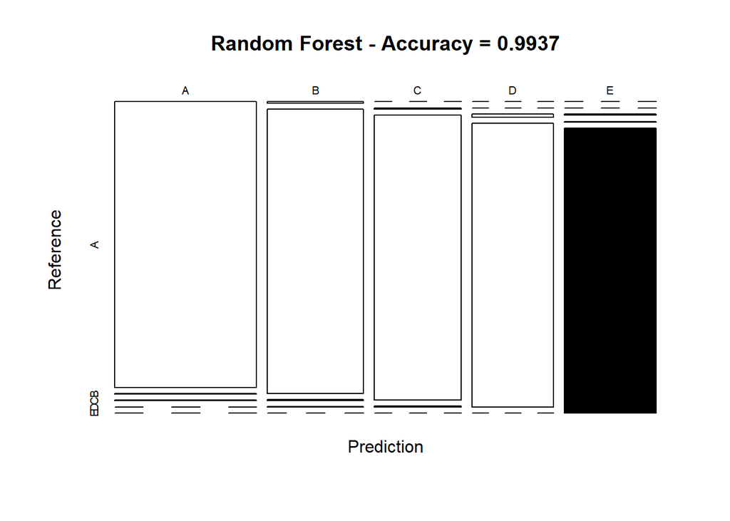

```r
plot(confMatRF$table, col = confMatRF$byClass,
     main = paste("Random Forest - Accuracy =",
                  round(confMatRF$overall['Accuracy'], 4)))
```

```r
errv <- 1 - as.numeric(confMatRF$overall[1])
errv
```

```
## [1] 0.006287171
```

So, the estimated accuracy of the model is 99.37% and the estimated out-of-sample error is 0.62%.

### Method 2 : Decision Tree

Next we apply the decision tree algorithm.

```r
set.seed(22519)
modelDT <- rpart(classe ~ ., data=trainData, method="class")
```

[figure not shown]

```r
fancyRpartPlot(modelDT)
```

We then validate the model on the testData to find out how well it performs by looking at the accuracy variable.

```r
predictDT <- predict(modelDT, newdata=testData, type="class")
confMatDT <- confusionMatrix(factor(predictDT), factor(testData$classe))
confMatDT
```

```
## Confusion Matrix and Statistics
##
##           Reference
## Prediction    A    B    C    D    E
##          A 1502  162   24   60   18
##          B   62  674   78   87   99
##          C   44  159  825   74   92
##          D   52   76   70  660   71
##          E   14   68   29   83  802
##
## Overall Statistics
##
##                Accuracy : 0.7584
##                  95% CI : (0.7472, 0.7693)
##     No Information Rate : 0.2845
##     P-Value [Acc > NIR] : < 2.2e-16
##
##                   Kappa : 0.6939
##
##  Mcnemar's Test P-Value : < 2.2e-16
##
## Statistics by Class:
##
##                      Class: A Class: B Class: C Class: D Class: E
## Sensitivity            0.8973   0.5917   0.8041   0.6846   0.7412
## Specificity            0.9373   0.9313   0.9241   0.9453   0.9596
## Pos Pred Value         0.8505   0.6740   0.6910   0.7104   0.8052
## Neg Pred Value         0.9582   0.9048   0.9572   0.9387   0.9427
## Prevalence             0.2845   0.1935   0.1743   0.1638   0.1839
## Detection Rate         0.2552   0.1145   0.1402   0.1121   0.1363
## Detection Prevalence   0.3001   0.1699   0.2029   0.1579   0.1692
## Balanced Accuracy      0.9173   0.7615   0.8641   0.8150   0.8504
```

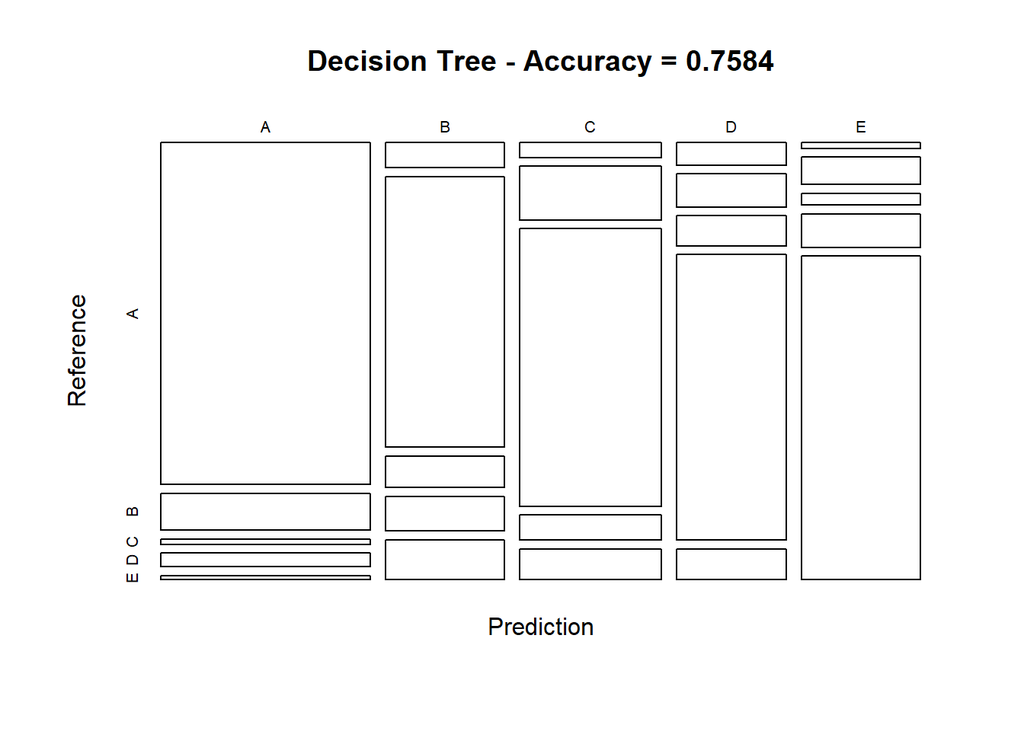

```r
plot(confMatDT$table, col = confMatDT$byClass,
     main = paste("Decision Tree - Accuracy =",
                  round(confMatDT$overall['Accuracy'], 4)))
```

### Method 3: Generalized Boosted Model

```r
set.seed(22519)
controlGBM <- trainControl(method = "repeatedcv", number = 5,
                           repeats = 1)
modelGBM  <- train(classe ~ ., data=trainData, method = "gbm",
                   trControl = controlGBM, verbose = FALSE)
modelGBM$finalModel
```

```
## A gradient boosted model with multinomial loss function.
## 150 iterations were performed.
## There were 52 predictors of which 52 had non-zero influence.
```

```r
predictGBM <- predict(modelGBM, newdata=testData)
confMatGBM <- confusionMatrix(factor(predictGBM),
                              factor(testData$classe))
confMatGBM
```

```
## Confusion Matrix and Statistics
##
##           Reference
## Prediction    A    B    C    D    E
##          A 1653   32    0    1    0
##          B   12 1077   18    4   14
##          C    7   26  993   25    6
##          D    2    3   13  925   23
##          E    0    1    2    9 1039
##
## Overall Statistics
##
##                Accuracy : 0.9664
##                  95% CI : (0.9614, 0.9708)
##     No Information Rate : 0.2845
##     P-Value [Acc > NIR] : < 2.2e-16
##
##                   Kappa : 0.9574
##
##  Mcnemar's Test P-Value : NA
##
## Statistics by Class:
##
##                      Class: A Class: B Class: C Class: D Class: E
## Sensitivity            0.9875   0.9456   0.9678   0.9595   0.9603
## Specificity            0.9922   0.9899   0.9868   0.9917   0.9975
## Pos Pred Value         0.9804   0.9573   0.9395   0.9576   0.9886
## Neg Pred Value         0.9950   0.9870   0.9932   0.9921   0.9911
## Prevalence             0.2845   0.1935   0.1743   0.1638   0.1839
## Detection Rate         0.2809   0.1830   0.1687   0.1572   0.1766
## Detection Prevalence   0.2865   0.1912   0.1796   0.1641   0.1786
## Balanced Accuracy      0.9898   0.9677   0.9773   0.9756   0.9789
```

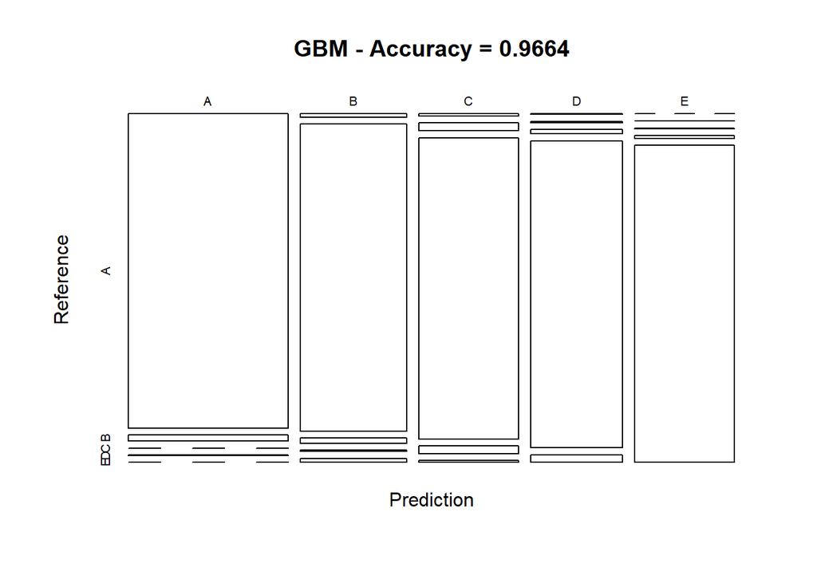

```r
plot(confMatGBM$table, col = confMatGBM$byClass,
     main = paste("GBM - Accuracy =",
                  round(confMatGBM$overall['Accuracy'], 4)))
```

## Predicting for Test Data Set

We noticed that the accuracy level is highest in case of Random forest method i.e. around 99%. Hence,we apply the RF model to the original testing data set downloaded from the data source. We remove the `problem_id` column first.

```r
result <- predict(modelRf,
                  testCleaned[,-length(names(testCleaned))])
result
```

```
##  [1] B A B A A E D B A A B C B A E E A B B B
## Levels: A B C D E
```

## Appendix: Figures

1. Correlation Matrix Visualization

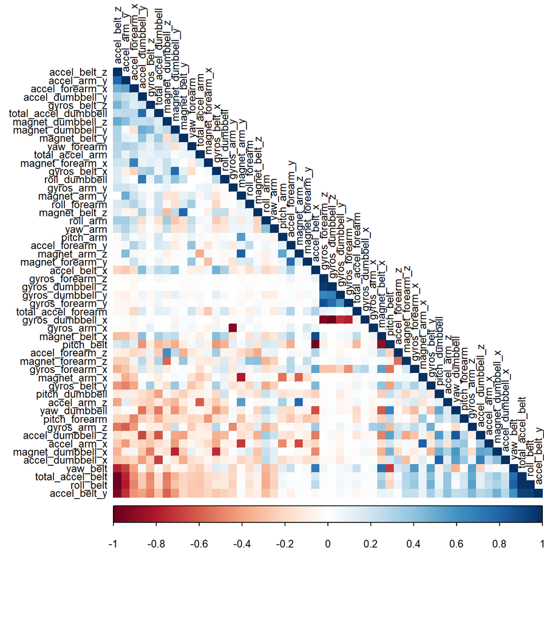

```r
corrPlot <- cor(trainData[, -length(names(trainData))])
corrplot(corrPlot, order = "FPC", method = "color", type = "lower", tl.cex = 0.8, tl.col = rgb(0, 0, 0))
```

## Data Reference

The data for this project come from http://groupware.les.inf.puc-rio.br/har.

Full source:  
Velloso, E.; Bulling, A.; Gellersen, H.; Ugulino, W.; Fuks, H. “Qualitative Activity Recognition of Weight Lifting Exercises. Proceedings of 4th International Conference in Cooperation with SIGCHI (Augmented Human ’13)”. Stuttgart, Germany: ACM SIGCHI, 2013.